# R Notebook

In this project, we are going to predict the churn customer of telecom sector and find out the key drivers that lead to churn. We are going to show how the logistic regression model using R can be used to identify the customer churn in telecome dataset.

Customer churn refers to a decision made by the customer about ending the business relationship. It is also referred to the loss of clients or customers. Customer loyalty and customer churn always add up to 100%. If a firm has a 60% loyalty rate, then their loss or churn rate of customers is 40%. As per 80/20 customer profitability rule, 20% of customers are generating 80% of revenue. So, it is very important to predict the users likely to churn from the business relationship and the factors affecting the customer decisions. Here we are going to show how logistic regression model using R can be used to identify the customer churn in the telecom dataset.

In this project we will seek answers for the following questions: 1. How to identify who is likely to churn 2. What are the factors responsible for churn? 3. Who are most valuable customers 4. How valid is the churn prediction model?

```r
#Loading Train and Test dataset

train = read.csv("https://s3.amazonaws.com/hackerday.datascience/104/Telecom_Train.csv")

test = read.csv("https://s3.amazonaws.com/hackerday.datascience/104/Telecom_Test.csv")
```

```r
train_df = train[,-1]
str(train_df)
```

```
'data.frame':   3333 obs. of  20 variables:
 $ state                        : Factor w/ 51 levels "AK","AL","AR",..: 17 36 32 36 37 2 20 25 19 50 ...
 $ account_length               : int  128 107 137 84 75 118 121 147 117 141 ...
 $ area_code                    : Factor w/ 3 levels "area_code_408",..: 2 2 2 1 2 3 3 2 1 2 ...
 $ international_plan           : Factor w/ 2 levels "no","yes": 1 1 1 2 2 2 1 2 1 2 ...
 $ voice_mail_plan              : Factor w/ 2 levels "no","yes": 2 2 1 1 1 1 2 1 1 2 ...
 $ number_vmail_messages        : int  25 26 0 0 0 0 24 0 0 37 ...
 $ total_day_minutes            : num  265 162 243 299 167 ...
 $ total_day_calls              : int  110 123 114 71 113 98 88 79 97 84 ...
 $ total_day_charge             : num  45.1 27.5 41.4 50.9 28.3 ...
 $ total_eve_minutes            : num  197.4 195.5 121.2 61.9 148.3 ...
 $ total_eve_calls              : int  99 103 110 88 122 101 108 94 80 111 ...
 $ total_eve_charge             : num  16.78 16.62 10.3 5.26 12.61 ...
 $ total_night_minutes          : num  245 254 163 197 187 ...
 $ total_night_calls            : int  91 103 104 89 121 118 118 96 90 97 ...
 $ total_night_charge           : num  11.01 11.45 7.32 8.86 8.41 ...
 $ total_intl_minutes           : num  10 13.7 12.2 6.6 10.1 6.3 7.5 7.1 8.7 11.2 ...
 $ total_intl_calls             : int  3 3 5 7 3 6 7 6 4 5 ...
 $ total_intl_charge            : num  2.7 3.7 3.29 1.78 2.73 1.7 2.03 1.92 2.35 3.02 ...
 $ number_customer_service_calls: int  1 1 0 2 3 0 3 0 1 0 ...
 $ churn                        : Factor w/ 2 levels "no","yes": 1 1 1 1 1 1 1 1 1 1 ...
```

```r
test_df = test[,-1]
str(test_df)
```

```
'data.frame':   1667 obs. of  20 variables:
 $ state                        : Factor w/ 51 levels "AK","AL","AR",..: 12 27 36 33 41 13 29 19 25 44 ...
 $ account_length               : int  101 137 103 99 108 117 63 94 138 128 ...
 $ area_code                    : Factor w/ 3 levels "area_code_408",..: 3 3 1 2 2 2 2 1 3 2 ...
 $ international_plan           : Factor w/ 2 levels "no","yes": 1 1 1 1 1 1 1 1 1 1 ...
 $ voice_mail_plan              : Factor w/ 2 levels "no","yes": 1 1 2 1 1 1 2 1 1 2 ...
 $ number_vmail_messages        : int  0 0 29 0 0 0 32 0 0 43 ...
 $ total_day_minutes            : num  70.9 223.6 294.7 216.8 197.4 ...
 $ total_day_calls              : int  123 86 95 123 78 85 124 97 117 100 ...
 $ total_day_charge             : num  12.1 38 50.1 36.9 33.6 ...
 $ total_eve_minutes            : num  212 245 237 126 124 ...
 $ total_eve_calls              : int  73 139 105 88 101 68 125 112 46 89 ...
 $ total_eve_charge             : num  18 20.8 20.2 10.7 10.5 ...
 $ total_night_minutes          : num  236 94.2 300.3 220.6 204.5 ...
 $ total_night_calls            : int  73 81 127 82 107 90 120 106 71 92 ...
 $ total_night_charge           : num  10.62 4.24 13.51 9.93 9.2 ...
 $ total_intl_minutes           : num  10.6 9.5 13.7 15.7 7.7 6.9 12.9 11.1 9.9 11.9 ...
 $ total_intl_calls             : int  3 7 6 2 4 5 3 6 4 1 ...
 $ total_intl_charge            : num  2.86 2.57 3.7 4.24 2.08 1.86 3.48 3 2.67 3.21 ...
 $ number_customer_service_calls: int  3 0 1 1 2 1 1 0 2 0 ...
 $ churn                        : Factor w/ 2 levels "no","yes": 1 1 1 1 1 1 1 1 1 1 ...
```

[output not shown]

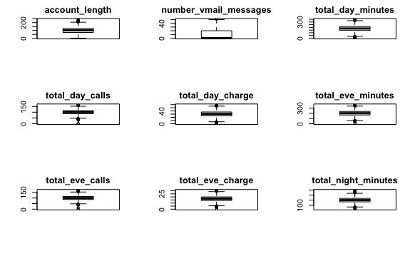

[output not shown]

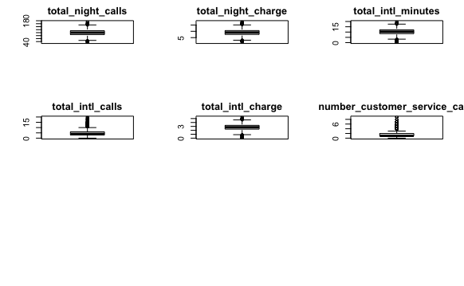

```r
head(traindf)
```

|  | account_length | number_vmail_messages | total_day_minutes | total_day_calls | total_day_charge | total_eve_minutes | total_eve_calls | total_eve_charge | total_night_minutes | total_night_calls | total_night_charge | total_intl_minutes | total_intl_calls | total_intl_charge | number_customer_service_calls | churn |
| --- | --- | --- | --- | --- | --- | --- | --- | --- | --- | --- | --- | --- | --- | --- | --- | --- |
| 1 | 128 | 25 | 265.1 | 110 | 45.07 | 197.4 | 99 | 16.78 | 244.7 | 91 | 11.01 | 10.0 | 3 | 2.70 | 1 | no |
| 2 | 107 | 26 | 161.6 | 123 | 27.47 | 195.5 | 103 | 16.62 | 254.4 | 103 | 11.45 | 13.7 | 3 | 3.70 | 1 | no |
| 3 | 137 | 0 | 243.4 | 114 | 41.38 | 121.2 | 110 | 10.30 | 162.6 | 104 | 7.32 | 12.2 | 5 | 3.29 | 0 | no |
| 4 | 84 | 0 | 299.4 | 71 | 50.90 | 61.9 | 88 | 5.26 | 196.9 | 89 | 8.86 | 6.6 | 7 | 1.78 | 2 | no |
| 5 | 75 | 0 | 166.7 | 113 | 28.34 | 148.3 | 122 | 12.61 | 186.9 | 121 | 8.41 | 10.1 | 3 | 2.73 | 3 | no |
| 6 | 118 | 0 | 223.4 | 98 | 37.98 | 220.6 | 101 | 18.75 | 203.9 | 118 | 9.18 | 6.3 | 6 | 1.70 | 0 | no |

```r
par(mfrow=c(2,1))
barplot(table(train$state))
barplot(table(train$area_code))
```

[output not shown]

```r
barplot(table(train$international_plan))
barplot(table(train$voice_mail_plan))
```

[output not shown]

```r
barplot(table(train$churn))
```

[output not shown]

```r
table(train_df$state)
```

```
 AK  AL  AR  AZ  CA  CO  CT  DC  DE  FL  GA  HI  IA  ID  IL  IN  KS  KY  LA
 52  80  55  64  34  66  74  54  61  63  54  53  44  73  58  71  70  59  51
 MA  MD  ME  MI  MN  MO  MS  MT  NC  ND  NE  NH  NJ  NM  NV  NY  OH  OK  OR
 65  70  62  73  84  63  65  68  68  62  61  56  68  62  66  83  78  61  78
 PA  RI  SC  SD  TN  TX  UT  VA  VT  WA  WI  WV  WY
 45  65  60  60  53  72  72  77  73  66  78 106  77
```

```r
#install.packages("dummy")
library(dummy)
```

```r
# Create dummy variables
train_cat = train_df[,c(-2,-4:-20)]
traincat = dummy(train_cat,p='all')
test_cat = test_df[,c(-2,-4:-20)]
testcat = dummy(test_cat,p='all')
```

```r
# Final training dataset
final_train = data.frame(traindf,traincat)
dim(final_train)
```

```
[1] 3333   70
```

```r
# Final test dataset
final_test = data.frame(testdf,testcat)
dim(final_test)
```

```
[1] 1667   70
```

```r
# Install and load caret, mlr and e1071 package
#install.packages("caret")
#install.packages("mlr")
library(caret)
library(mlr)
#install.packages("e1071")
library(e1071)
```

```r
# Basic logistic regression based classifier on DATA SET
fit_glm = glm(churn~.,data=final_train,
              family = binomial(link = 'logit'))
summary(fit_glm)
```

```
Call:
glm(formula = churn ~ ., family = binomial(link = "logit"), data = final_train)

Deviance Residuals:
    Min       1Q   Median       3Q      Max
-1.6404  -0.5554  -0.3794  -0.2240   2.9519

Coefficients: (2 not defined because of singularities)
                                Estimate Std. Error z value Pr(>|z|)
(Intercept)                   -8.5029057  0.8207061 -10.360  < 2e-16 ***
account_length                 0.0015551  0.0013658   1.139  0.25486
number_vmail_messages         -0.0250592  0.0046217  -5.422 5.89e-08 ***
total_day_minutes             -0.6431009  3.2148107  -0.200  0.84145
total_day_calls                0.0036491  0.0027225   1.340  0.18014
total_day_charge               3.8574669 18.9108146   0.204  0.83837
total_eve_minutes              0.6365689  1.6146073   0.394  0.69339
total_eve_calls                0.0008503  0.0027136   0.313  0.75401
total_eve_charge              -7.4089623 18.9952201  -0.390  0.69650
total_night_minutes           -0.0530556  0.8579085  -0.062  0.95069
total_night_calls              0.0005456  0.0027870   0.196  0.84479
total_night_charge             1.2446449 19.0639545   0.065  0.94794
total_intl_minutes            -1.2336313  5.1698172  -0.239  0.81140
total_intl_calls              -0.0776120  0.0243881  -3.182  0.00146 **
total_intl_charge              4.9037057 19.1464233   0.256  0.79786
number_customer_service_calls  0.4694927  0.0384849  12.199  < 2e-16 ***
state_AK1                     -0.4845188  0.7259070  -0.667  0.50447
state_AL1                     -0.0677130  0.5527696  -0.122  0.90250
state_AR1                      0.6156203  0.5352986   1.150  0.25012
state_AZ1                     -0.4266413  0.6604253  -0.646  0.51827
state_CA1                      1.3349543  0.5736155   2.327  0.01995 *
state_CO1                      0.1155445  0.5533240   0.209  0.83459
state_CT1                      0.5539504  0.5168608   1.072  0.28383
state_DC1                      0.0848473  0.6222050   0.136  0.89153
state_DE1                      0.4236544  0.5413842   0.783  0.43390
state_FL1                      0.1981504  0.5562799   0.356  0.72169
state_GA1                      0.1549715  0.5671110   0.273  0.78465
state_HI1                     -0.7524782  0.7316517  -1.028  0.30373
state_IA1                     -0.5226305  0.7360903  -0.710  0.47770
state_ID1                      0.2040759  0.5405614   0.378  0.70578
state_IL1                     -0.0311819  0.6222117  -0.050  0.96003
```

[output cut: 34 more lines]

```
state_WV1                      0.0740588  0.5176394   0.143  0.88623
state_WY1                             NA         NA      NA       NA
area_code_area_code_4081       0.0061884  0.1537686   0.040  0.96790
area_code_area_code_4151      -0.0668167  0.1315267  -0.508  0.61145
area_code_area_code_5101              NA         NA      NA       NA
---
Signif. codes:  0 ‘***’ 0.001 ‘**’ 0.01 ‘*’ 0.05 ‘.’ 0.1 ‘ ’ 1

(Dispersion parameter for binomial family taken to be 1)

    Null deviance: 2758.3  on 3332  degrees of freedom
Residual deviance: 2286.4  on 3265  degrees of freedom
AIC: 2422.4

Number of Fisher Scoring iterations: 5
```

```r
pred = predict(fit_glm, final_train)
```

```
prediction from a rank-deficient fit may be misleading
```

```r
#add pred to data train
final_train$pred = ifelse(predict(fit_glm, final_train, type='response')>0.5,'yes','no')
```

```
prediction from a rank-deficient fit may be misleading
```

```r
confusionMatrix(final_train$churn,final_train$pred)
```

```
Confusion Matrix and Statistics

          Reference
Prediction   no  yes
       no  2801   49
       yes  411   72

               Accuracy : 0.862
                 95% CI : (0.8498, 0.8735)
    No Information Rate : 0.9637
    P-Value [Acc > NIR] : 1

                  Kappa : 0.1915
 Mcnemar's Test P-Value : <2e-16

            Sensitivity : 0.8720
            Specificity : 0.5950
         Pos Pred Value : 0.9828
         Neg Pred Value : 0.1491
             Prevalence : 0.9637
         Detection Rate : 0.8404
   Detection Prevalence : 0.8551
      Balanced Accuracy : 0.7335

       'Positive' Class : no
```

```r
# basic logistic regression based classifier on TEST SET
fit_glm = glm(churn~.,data=final_test,
              family = binomial(link = 'logit'))
summary(fit_glm)
```

```
Call:
glm(formula = churn ~ ., family = binomial(link = "logit"), data = final_test)

Deviance Residuals:
    Min       1Q   Median       3Q      Max
-1.8163  -0.5146  -0.3229  -0.1673   2.9577

Coefficients: (2 not defined because of singularities)
                                Estimate Std. Error z value Pr(>|z|)
(Intercept)                    -7.956679   1.294918  -6.145 8.02e-10 ***
account_length                  0.001516   0.002074   0.731   0.4649
number_vmail_messages          -0.042200   0.008303  -5.082 3.73e-07 ***
total_day_minutes              11.089900   4.930647   2.249   0.0245 *
total_day_calls                 0.001593   0.004312   0.369   0.7118
total_day_charge              -65.151756  29.003237  -2.246   0.0247 *
total_eve_minutes              -0.924739   2.442639  -0.379   0.7050
total_eve_calls                -0.007042   0.004340  -1.623   0.1047
total_eve_charge               10.959251  28.736715   0.381   0.7029
total_night_minutes             0.538415   1.302828   0.413   0.6794
total_night_calls              -0.006222   0.004031  -1.544   0.1227
total_night_charge            -11.875520  28.951840  -0.410   0.6817
total_intl_minutes              7.428882   7.885171   0.942   0.3461
total_intl_calls               -0.043022   0.033986  -1.266   0.2056
total_intl_charge             -27.202122  29.212286  -0.931   0.3518
number_customer_service_calls   0.493150   0.059820   8.244  < 2e-16 ***
state_AK1                       0.729627   1.132275   0.644   0.5193
state_AL1                       0.683978   0.907889   0.753   0.4512
state_AR1                       1.594958   0.925035   1.724   0.0847 .
state_AZ1                       1.681374   0.943480   1.782   0.0747 .
state_CA1                       2.199115   0.961017   2.288   0.0221 *
state_CO1                       0.486808   1.081106   0.450   0.6525
state_CT1                       1.128729   0.970298   1.163   0.2447
state_DC1                       1.077160   0.960222   1.122   0.2620
state_DE1                       0.788353   0.923468   0.854   0.3933
state_FL1                       1.090019   0.970639   1.123   0.2614
state_GA1                       0.157734   1.086852   0.145   0.8846
state_HI1                      -0.011466   1.072828  -0.011   0.9915
state_IA1                       1.553513   0.950154   1.635   0.1020
state_ID1                       0.527026   0.915934   0.575   0.5650
state_IL1                       0.203706   1.082626   0.188   0.8508
```

[output cut: 34 more lines]

```
state_WV1                       1.463564   0.853117   1.716   0.0862 .
state_WY1                             NA         NA      NA       NA
area_code_area_code_4081       -0.142309   0.232636  -0.612   0.5407
area_code_area_code_4151       -0.157683   0.201024  -0.784   0.4328
area_code_area_code_5101              NA         NA      NA       NA
---
Signif. codes:  0 ‘***’ 0.001 ‘**’ 0.01 ‘*’ 0.05 ‘.’ 0.1 ‘ ’ 1

(Dispersion parameter for binomial family taken to be 1)

    Null deviance: 1315.7  on 1666  degrees of freedom
Residual deviance: 1025.3  on 1599  degrees of freedom
AIC: 1161.3

Number of Fisher Scoring iterations: 15
```

```r
pred = predict(fit_glm, final_test)
```

```
prediction from a rank-deficient fit may be misleading
```

```r
#add pred to data train
final_test$pred = ifelse(predict(fit_glm, final_test, type='response')>0.5,'yes','no')
```

```
prediction from a rank-deficient fit may be misleading
```

```r
confusionMatrix(final_test$churn,final_test$pred)
```

```
Confusion Matrix and Statistics

          Reference
Prediction   no  yes
       no  1418   25
       yes  182   42

               Accuracy : 0.8758
                 95% CI : (0.859, 0.8913)
    No Information Rate : 0.9598
    P-Value [Acc > NIR] : 1

                  Kappa : 0.2417
 Mcnemar's Test P-Value : <2e-16

            Sensitivity : 0.8862
            Specificity : 0.6269
         Pos Pred Value : 0.9827
         Neg Pred Value : 0.1875
             Prevalence : 0.9598
         Detection Rate : 0.8506
   Detection Prevalence : 0.8656
      Balanced Accuracy : 0.7566

       'Positive' Class : no
```

```r
# Above result shows that Kappa Value (Reliability) is very weak
# If I change the threshold proability (e.g. from 0.5 to 0.6) will that change the reliability statistics
# the split of probability should be in confirmity with train dataset
(table(final_train$churn)/nrow(final_train)*100)
```

```
      no      yes
85.50855 14.49145
```

```r
(table(final_train$pred)/nrow(final_train)*100)
```

```
       no       yes
96.369637  3.630363
```

```r
(table(final_test$churn)/nrow(final_test)*100)
```

```
      no      yes
86.56269 13.43731
```

```r
(table(final_test$pred)/nrow(final_test)*100)
```

```
       no       yes
95.980804  4.019196
```

```r
### RUN 2
# If I change the threshold proability (e.g. from 0.5 to 0.4) will that change the reliability statistics
fit_glm = glm(churn~.,data=final_train,
              family = binomial(link = 'logit'))
summary(fit_glm)
```

```
Call:
glm(formula = churn ~ ., family = binomial(link = "logit"), data = final_train)

Deviance Residuals:
    Min       1Q   Median       3Q      Max
-1.6050  -0.5563  -0.3764  -0.2209   2.9667

Coefficients: (2 not defined because of singularities)
                                Estimate Std. Error z value Pr(>|z|)
(Intercept)                   -8.6354309  0.8542913 -10.108  < 2e-16 ***
account_length                 0.0016282  0.0013711   1.188  0.23502
number_vmail_messages         -0.0254150  0.0046678  -5.445 5.19e-08 ***
total_day_minutes             -0.6218895  3.2126861  -0.194  0.84651
total_day_calls                0.0037476  0.0027265   1.375  0.16928
total_day_charge               3.7340806 18.8982870   0.198  0.84337
total_eve_minutes              0.6383622  1.6135670   0.396  0.69238
total_eve_calls                0.0008646  0.0027111   0.319  0.74981
total_eve_charge              -7.4286381 18.9829776  -0.391  0.69555
total_night_minutes           -0.0697818  0.8577145  -0.081  0.93516
total_night_calls              0.0005650  0.0027855   0.203  0.83926
total_night_charge             1.6177030 19.0597248   0.085  0.93236
total_intl_minutes            -1.3324406  5.1699629  -0.258  0.79662
total_intl_calls              -0.0790229  0.0245281  -3.222  0.00127 **
total_intl_charge              5.2764681 19.1473569   0.276  0.78288
number_customer_service_calls  0.4797889  0.0425648  11.272  < 2e-16 ***
state_AK1                     -0.4887803  0.7267378  -0.673  0.50122
state_AL1                     -0.0698611  0.5530199  -0.126  0.89947
state_AR1                      0.6186263  0.5349546   1.156  0.24751
state_AZ1                     -0.4329696  0.6612255  -0.655  0.51260
state_CA1                      1.3582309  0.5739191   2.367  0.01795 *
state_CO1                      0.1249772  0.5526442   0.226  0.82109
state_CT1                      0.5604941  0.5166628   1.085  0.27799
state_DC1                      0.0828161  0.6227450   0.133  0.89420
state_DE1                      0.4249718  0.5414849   0.785  0.43256
state_FL1                      0.1923403  0.5568986   0.345  0.72981
state_GA1                      0.1550928  0.5666852   0.274  0.78433
state_HI1                     -0.7651135  0.7331883  -1.044  0.29670
state_IA1                     -0.5319263  0.7373375  -0.721  0.47065
state_ID1                      0.2025475  0.5407223   0.375  0.70797
state_IL1                     -0.0349021  0.6228176  -0.056  0.95531
```

[output cut: 35 more lines]

```
state_WY1                             NA         NA      NA       NA
area_code_area_code_4081       0.0103370  0.1537717   0.067  0.94640
area_code_area_code_4151      -0.0696560  0.1315474  -0.530  0.59645
area_code_area_code_5101              NA         NA      NA       NA
predyes                       -0.1367009  0.2412615  -0.567  0.57098
---
Signif. codes:  0 ‘***’ 0.001 ‘**’ 0.01 ‘*’ 0.05 ‘.’ 0.1 ‘ ’ 1

(Dispersion parameter for binomial family taken to be 1)

    Null deviance: 2758.3  on 3332  degrees of freedom
Residual deviance: 2286.0  on 3264  degrees of freedom
AIC: 2424

Number of Fisher Scoring iterations: 6
```

```r
pred = predict(fit_glm, final_train)
```

```
prediction from a rank-deficient fit may be misleading
```

```r
#add pred to data train
final_train$pred = ifelse(predict(fit_glm, final_train, type='response')>0.4,'yes','no')
```

```
prediction from a rank-deficient fit may be misleading
```

```r
confusionMatrix(final_train$churn,final_train$pred)
```

```
Confusion Matrix and Statistics

          Reference
Prediction   no  yes
       no  2749  101
       yes  354  129

               Accuracy : 0.8635
                 95% CI : (0.8514, 0.875)
    No Information Rate : 0.931
    P-Value [Acc > NIR] : 1

                  Kappa : 0.296
 Mcnemar's Test P-Value : <2e-16

            Sensitivity : 0.8859
            Specificity : 0.5609
         Pos Pred Value : 0.9646
         Neg Pred Value : 0.2671
             Prevalence : 0.9310
         Detection Rate : 0.8248
   Detection Prevalence : 0.8551
      Balanced Accuracy : 0.7234

       'Positive' Class : no
```

```r
fit_glm = glm(churn~.,data=final_test,
              family = binomial(link = 'logit'))
summary(fit_glm)
```

```
Call:
glm(formula = churn ~ ., family = binomial(link = "logit"), data = final_test)

Deviance Residuals:
    Min       1Q   Median       3Q      Max
-1.7815  -0.5161  -0.3196  -0.1628   2.9879

Coefficients: (2 not defined because of singularities)
                                Estimate Std. Error z value Pr(>|z|)
(Intercept)                    -8.104894   1.326250  -6.111 9.89e-10 ***
account_length                  0.001563   0.002073   0.754   0.4510
number_vmail_messages          -0.043189   0.008534  -5.061 4.17e-07 ***
total_day_minutes              11.194344   4.929366   2.271   0.0231 *
total_day_calls                 0.001488   0.004313   0.345   0.7301
total_day_charge              -65.763959  28.995526  -2.268   0.0233 *
total_eve_minutes              -0.994758   2.443687  -0.407   0.6840
total_eve_calls                -0.007203   0.004349  -1.656   0.0977 .
total_eve_charge               11.784606  28.749208   0.410   0.6819
total_night_minutes             0.550935   1.302186   0.423   0.6722
total_night_calls              -0.006404   0.004041  -1.585   0.1130
total_night_charge            -12.150030  28.937442  -0.420   0.6746
total_intl_minutes              7.777034   7.904130   0.984   0.3252
total_intl_calls               -0.044595   0.034096  -1.308   0.1909
total_intl_charge             -28.480374  29.280759  -0.973   0.3307
number_customer_service_calls   0.509859   0.067435   7.561 4.01e-14 ***
state_AK1                       0.735310   1.137452   0.646   0.5180
state_AL1                       0.689741   0.910216   0.758   0.4486
state_AR1                       1.627259   0.928835   1.752   0.0798 .
state_AZ1                       1.723302   0.947156   1.819   0.0688 .
state_CA1                       2.258823   0.967212   2.335   0.0195 *
state_CO1                       0.499287   1.084173   0.461   0.6451
state_CT1                       1.159856   0.972495   1.193   0.2330
state_DC1                       1.100432   0.962499   1.143   0.2529
state_DE1                       0.809110   0.924796   0.875   0.3816
state_FL1                       1.110125   0.972829   1.141   0.2538
state_GA1                       0.156657   1.090117   0.144   0.8857
state_HI1                      -0.008877   1.075179  -0.008   0.9934
state_IA1                       1.569776   0.952359   1.648   0.0993 .
state_ID1                       0.537080   0.917888   0.585   0.5585
state_IL1                       0.205607   1.085381   0.189   0.8498
```

[output cut: 35 more lines]

```
state_WY1                             NA         NA      NA       NA
area_code_area_code_4081       -0.154109   0.233355  -0.660   0.5090
area_code_area_code_4151       -0.167761   0.201533  -0.832   0.4052
area_code_area_code_5101              NA         NA      NA       NA
predyes                        -0.188799   0.351336  -0.537   0.5910
---
Signif. codes:  0 ‘***’ 0.001 ‘**’ 0.01 ‘*’ 0.05 ‘.’ 0.1 ‘ ’ 1

(Dispersion parameter for binomial family taken to be 1)

    Null deviance: 1315.7  on 1666  degrees of freedom
Residual deviance: 1025.0  on 1598  degrees of freedom
AIC: 1163

Number of Fisher Scoring iterations: 15
```

```r
pred = predict(fit_glm, final_test)
```

```
prediction from a rank-deficient fit may be misleading
```

```r
#add pred to data train
final_test$pred = ifelse(predict(fit_glm, final_test, type='response')>0.4,'yes','no')
```

```
prediction from a rank-deficient fit may be misleading
```

```r
confusionMatrix(final_test$churn,final_test$pred)
```

```
Confusion Matrix and Statistics

          Reference
Prediction   no  yes
       no  1391   52
       yes  145   79

               Accuracy : 0.8818
                 95% CI : (0.8654, 0.8969)
    No Information Rate : 0.9214
    P-Value [Acc > NIR] : 1

                  Kappa : 0.384
 Mcnemar's Test P-Value : 5.574e-11

            Sensitivity : 0.9056
            Specificity : 0.6031
         Pos Pred Value : 0.9640
         Neg Pred Value : 0.3527
             Prevalence : 0.9214
         Detection Rate : 0.8344
   Detection Prevalence : 0.8656
      Balanced Accuracy : 0.7543

       'Positive' Class : no
```

```r
(table(final_train$churn)/nrow(final_train)*100)
```

```
      no      yes
85.50855 14.49145
```

```r
(table(final_train$pred)/nrow(final_train)*100)
```

```
      no      yes
93.09931  6.90069
```

```r
(table(final_test$churn)/nrow(final_test)*100)
```

```
      no      yes
86.56269 13.43731
```

```r
(table(final_test$pred)/nrow(final_test)*100)
```

```
       no       yes
92.141572  7.858428
```

```r
# Run 3 - Check Kappa (must be high) and no yes between predict and churn (must be in accordance)
fit_glm = glm(churn~.,data=final_train,
              family = binomial(link = 'logit'))
summary(fit_glm)
```

```
Call:
glm(formula = churn ~ ., family = binomial(link = "logit"), data = final_train)

Deviance Residuals:
    Min       1Q   Median       3Q      Max
-1.6745  -0.5513  -0.3842  -0.2337   2.9100

Coefficients: (2 not defined because of singularities)
                                Estimate Std. Error z value Pr(>|z|)
(Intercept)                   -8.1489606  0.8669181  -9.400  < 2e-16 ***
account_length                 0.0014511  0.0013711   1.058  0.28990
number_vmail_messages         -0.0237164  0.0047348  -5.009 5.47e-07 ***
total_day_minutes             -0.7037769  3.2229753  -0.218  0.82715
total_day_calls                0.0034339  0.0027348   1.256  0.20925
total_day_charge               4.2101528 18.9587870   0.222  0.82426
total_eve_minutes              0.5974485  1.6183580   0.369  0.71200
total_eve_calls                0.0008734  0.0027226   0.321  0.74836
total_eve_charge              -6.9532194 19.0392830  -0.365  0.71496
total_night_minutes           -0.0107597  0.8609940  -0.012  0.99003
total_night_calls              0.0005998  0.0027937   0.215  0.83000
total_night_charge             0.3011613 19.1326370   0.016  0.98744
total_intl_minutes            -0.9431060  5.1862275  -0.182  0.85570
total_intl_calls              -0.0745647  0.0245162  -3.041  0.00235 **
total_intl_charge              3.8114095 19.2078180   0.198  0.84271
number_customer_service_calls  0.4411157  0.0447853   9.850  < 2e-16 ***
state_AK1                     -0.4741230  0.7241798  -0.655  0.51266
state_AL1                     -0.0669031  0.5525038  -0.121  0.90362
state_AR1                      0.5990122  0.5362373   1.117  0.26397
state_AZ1                     -0.4112579  0.6587618  -0.624  0.53244
state_CA1                      1.2569191  0.5796250   2.169  0.03012 *
state_CO1                      0.0908553  0.5555689   0.164  0.87010
state_CT1                      0.5242410  0.5182783   1.012  0.31177
state_DC1                      0.0857922  0.6207020   0.138  0.89007
state_DE1                      0.4063527  0.5419997   0.750  0.45342
state_FL1                      0.1912971  0.5563464   0.344  0.73096
state_GA1                      0.1413397  0.5684909   0.249  0.80365
state_HI1                     -0.7183054  0.7294829  -0.985  0.32478
state_IA1                     -0.4952276  0.7334482  -0.675  0.49955
state_ID1                      0.1923882  0.5409910   0.356  0.72212
state_IL1                     -0.0243703  0.6207122  -0.039  0.96868
```

[output cut: 35 more lines]

```
state_WY1                             NA         NA      NA       NA
area_code_area_code_4081      -0.0073417  0.1545854  -0.047  0.96212
area_code_area_code_4151      -0.0660213  0.1317865  -0.501  0.61639
area_code_area_code_5101              NA         NA      NA       NA
predyes                        0.2462666  0.1995950   1.234  0.21727
---
Signif. codes:  0 ‘***’ 0.001 ‘**’ 0.01 ‘*’ 0.05 ‘.’ 0.1 ‘ ’ 1

(Dispersion parameter for binomial family taken to be 1)

    Null deviance: 2758.3  on 3332  degrees of freedom
Residual deviance: 2284.8  on 3264  degrees of freedom
AIC: 2422.8

Number of Fisher Scoring iterations: 6
```

```r
pred = predict(fit_glm, final_train)
```

```
prediction from a rank-deficient fit may be misleading
```

```r
#add pred to data train
final_train$pred = ifelse(predict(fit_glm, final_train, type='response')>0.3,'yes','no')
```

```
prediction from a rank-deficient fit may be misleading
```

```r
confusionMatrix(final_train$churn,final_train$pred)
```

```
Confusion Matrix and Statistics

          Reference
Prediction   no  yes
       no  2658  192
       yes  287  196

               Accuracy : 0.8563
                 95% CI : (0.8439, 0.868)
    No Information Rate : 0.8836
    P-Value [Acc > NIR] : 1

                  Kappa : 0.3685
 Mcnemar's Test P-Value : 1.747e-05

            Sensitivity : 0.9025
            Specificity : 0.5052
         Pos Pred Value : 0.9326
         Neg Pred Value : 0.4058
             Prevalence : 0.8836
         Detection Rate : 0.7975
   Detection Prevalence : 0.8551
      Balanced Accuracy : 0.7039

       'Positive' Class : no
```

```r
fit_glm = glm(churn~.,data=final_test,
              family = binomial(link = 'logit'))
summary(fit_glm)
```

```
Call:
glm(formula = churn ~ ., family = binomial(link = "logit"), data = final_test)

Deviance Residuals:
    Min       1Q   Median       3Q      Max
-1.8451  -0.5020  -0.3368  -0.1888   2.8335

Coefficients: (2 not defined because of singularities)
                                Estimate Std. Error z value Pr(>|z|)
(Intercept)                    -7.163381   1.342040  -5.338 9.41e-08 ***
account_length                  0.001462   0.002090   0.699   0.4843
number_vmail_messages          -0.036993   0.008567  -4.318 1.57e-05 ***
total_day_minutes               9.708854   5.006304   1.939   0.0525 .
total_day_calls                 0.001731   0.004350   0.398   0.6907
total_day_charge              -57.040550  29.447583  -1.937   0.0527 .
total_eve_minutes              -0.764858   2.461803  -0.311   0.7560
total_eve_calls                -0.005803   0.004406  -1.317   0.1878
total_eve_charge                9.066398  28.962386   0.313   0.7542
total_night_minutes             0.428914   1.312802   0.327   0.7439
total_night_calls              -0.005096   0.004092  -1.246   0.2129
total_night_charge             -9.458180  29.173190  -0.324   0.7458
total_intl_minutes              6.505691   7.967664   0.817   0.4142
total_intl_calls               -0.034340   0.034413  -0.998   0.3183
total_intl_charge             -23.841694  29.516204  -0.808   0.4192
number_customer_service_calls   0.422579   0.068678   6.153 7.60e-10 ***
state_AK1                       0.517211   1.143689   0.452   0.6511
state_AL1                       0.679068   0.897717   0.756   0.4494
state_AR1                       1.413214   0.922410   1.532   0.1255
state_AZ1                       1.485345   0.944781   1.572   0.1159
state_CA1                       1.917757   0.969522   1.978   0.0479 *
state_CO1                       0.430308   1.068913   0.403   0.6873
state_CT1                       0.968284   0.972301   0.996   0.3193
state_DC1                       0.930132   0.957834   0.971   0.3315
state_DE1                       0.640153   0.925427   0.692   0.4891
state_FL1                       0.966176   0.967618   0.999   0.3180
state_GA1                       0.167333   1.072400   0.156   0.8760
state_HI1                      -0.023566   1.062467  -0.022   0.9823
state_IA1                       1.382898   0.949422   1.457   0.1452
state_ID1                       0.458529   0.910466   0.504   0.6145
state_IL1                       0.192910   1.070194   0.180   0.8570
```

[output cut: 35 more lines]

```
state_WY1                             NA         NA      NA       NA
area_code_area_code_4081       -0.116040   0.234857  -0.494   0.6212
area_code_area_code_4151       -0.139174   0.203192  -0.685   0.4934
area_code_area_code_5101              NA         NA      NA       NA
predyes                         0.607330   0.293127   2.072   0.0383 *
---
Signif. codes:  0 ‘***’ 0.001 ‘**’ 0.01 ‘*’ 0.05 ‘.’ 0.1 ‘ ’ 1

(Dispersion parameter for binomial family taken to be 1)

    Null deviance: 1315.7  on 1666  degrees of freedom
Residual deviance: 1021.0  on 1598  degrees of freedom
AIC: 1159

Number of Fisher Scoring iterations: 15
```

```r
pred = predict(fit_glm, final_test)
```

```
prediction from a rank-deficient fit may be misleading
```

```r
#add pred to data train
final_test$pred = ifelse(predict(fit_glm, final_test, type='response')>0.3,'yes','no')
```

```
prediction from a rank-deficient fit may be misleading
```

```r
confusionMatrix(final_test$churn,final_test$pred)
```

```
Confusion Matrix and Statistics

          Reference
Prediction   no  yes
       no  1371   72
       yes  135   89

               Accuracy : 0.8758
                 95% CI : (0.859, 0.8913)
    No Information Rate : 0.9034
    P-Value [Acc > NIR] : 0.9999

                  Kappa : 0.3943
 Mcnemar's Test P-Value : 1.638e-05

            Sensitivity : 0.9104
            Specificity : 0.5528
         Pos Pred Value : 0.9501
         Neg Pred Value : 0.3973
             Prevalence : 0.9034
         Detection Rate : 0.8224
   Detection Prevalence : 0.8656
      Balanced Accuracy : 0.7316

       'Positive' Class : no
```

```r
(table(final_train$churn)/nrow(final_train)*100)
```

```
      no      yes
85.50855 14.49145
```

```r
(table(final_train$pred)/nrow(final_train)*100)
```

```
      no      yes
88.35884 11.64116
```

```r
(table(final_test$churn)/nrow(final_test)*100)
```

```
      no      yes
86.56269 13.43731
```

```r
(table(final_test$pred)/nrow(final_test)*100)
```

```
       no       yes
90.341932  9.658068
```

```r
## Even after changing threshold and prediction in conform with the pred, the Kappa value is still in minimum range
# Stabilize the result
# Cross validation to stabilize result
# Use Decision tree based method
library(caret)
library(mlr)
library(rpart)
train_control <- trainControl(method = 'cv', number = 10)
metric <- 'Accuracy'
fit_dt <- caret::train(churn~.,data=train_df,
               trControl = train_control,
               method='rpart')
## for rpart, no dummy needs to be created
fit_dt
```

```
CART

3333 samples
  19 predictor
   2 classes: 'no', 'yes'

No pre-processing
Resampling: Cross-Validated (10 fold)
Summary of sample sizes: 3000, 3000, 2999, 3000, 3000, 3000, ...
Resampling results across tuning parameters:

  cp          Accuracy   Kappa
  0.07867495  0.8820890  0.3750400
  0.08488613  0.8670937  0.2416394
  0.08902692  0.8577916  0.1592164

Accuracy was used to select the optimal model using  the largest value.
The final value used for the model was cp = 0.07867495.
```

```r
predictions <- predict(fit_dt, test_df)
pred = cbind(test_df, predictions)
confusionMatrix(pred$churn,pred$predictions)
```

```
Confusion Matrix and Statistics

          Reference
Prediction   no  yes
       no  1419   24
       yes  164   60

               Accuracy : 0.8872
                 95% CI : (0.8711, 0.902)
    No Information Rate : 0.9496
    P-Value [Acc > NIR] : 1

                  Kappa : 0.3413
 Mcnemar's Test P-Value : <2e-16

            Sensitivity : 0.8964
            Specificity : 0.7143
         Pos Pred Value : 0.9834
         Neg Pred Value : 0.2679
             Prevalence : 0.9496
         Detection Rate : 0.8512
   Detection Prevalence : 0.8656
      Balanced Accuracy : 0.8053

       'Positive' Class : no
```

```r
varImp(fit_dt)
```

```
rpart variable importance

  only 20 most important variables shown (out of 69)

                              Overall
total_day_minutes             100.000
total_day_charge               93.072
number_customer_service_calls  79.443
international_planyes          55.175
number_vmail_messages          33.443
voice_mail_planyes             33.443
total_eve_minutes              14.576
total_eve_charge               14.576
total_intl_minutes              8.563
stateTX                         0.000
stateIN                         0.000
total_intl_calls                0.000
stateOR                         0.000
stateMD                         0.000
stateSC                         0.000
stateMN                         0.000
stateDC                         0.000
stateVT                         0.000
total_intl_charge               0.000
stateAZ                         0.000
```

```r
# Decision tree based method
# install.packages("C50")
library(C50)
fit_dtc50 <- caret::train(churn~., data = train_df, trControl = train_control, method='C5.0')
fit_dtc50
```

```
C5.0

3333 samples
  19 predictor
   2 classes: 'no', 'yes'

No pre-processing
Resampling: Cross-Validated (10 fold)
Summary of sample sizes: 2999, 2999, 3000, 3000, 3000, 2999, ...
Resampling results across tuning parameters:

  model  winnow  trials  Accuracy   Kappa
  rules  FALSE    1      0.9439005  0.7580496
  rules  FALSE   10      0.9535029  0.7968866
  rules  FALSE   20      0.9583005  0.8195236
  rules   TRUE    1      0.9469053  0.7720133
  rules   TRUE   10      0.9582969  0.8187612
  rules   TRUE   20      0.9588993  0.8223403
  tree   FALSE    1      0.9454002  0.7613960
  tree   FALSE   10      0.9526083  0.7910490
  tree   FALSE   20      0.9564996  0.8092069
  tree    TRUE    1      0.9460008  0.7646370
  tree    TRUE   10      0.9526002  0.7881596
  tree    TRUE   20      0.9552975  0.8021696

Accuracy was used to select the optimal model using  the largest value.
The final values used for the model were trials = 20, model = rules
 and winnow = TRUE.
```

```r
predictions <- predict(fit_dtc50, test_df)
pred = cbind(test_df, predictions)
confusionMatrix(pred$churn,pred$predictions)
```

```
Confusion Matrix and Statistics

          Reference
Prediction   no  yes
       no  1431   12
       yes   55  169

               Accuracy : 0.9598
                 95% CI : (0.9492, 0.9687)
    No Information Rate : 0.8914
    P-Value [Acc > NIR] : < 2.2e-16

                  Kappa : 0.812
 Mcnemar's Test P-Value : 2.88e-07

            Sensitivity : 0.9630
            Specificity : 0.9337
         Pos Pred Value : 0.9917
         Neg Pred Value : 0.7545
             Prevalence : 0.8914
         Detection Rate : 0.8584
   Detection Prevalence : 0.8656
      Balanced Accuracy : 0.9483

       'Positive' Class : no
```

```r
varImp(train_df)
```

[output not shown]

```r
# Boosted Tree
#install.packages("bst")
library(bst)
fit_bstTree <- caret::train(churn~., data = train_df, trControl = train_control, method='bstTree')
```

```r
#install.packages("randomForest")
library(randomForest)
control <- caret::trainControl(method = 'repeatedcv',
                        number = 10,
                        repeats = 3,
                        search = 'random')
seed <- 1234
metric <- 'Accuracy'
set.seed(seed)
mtry <- sqrt(ncol(train_df))
fit_rf_random <- caret::train(churn~.,
                              data = train_df[1:500,],
                              method = 'rf',
                              metric=metric,
                              tuneLength=15,
                              trControl = control)
```

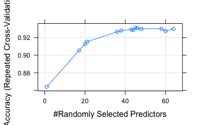

```r
plot(fit_rf_random)
```

```r
fit_rf_grid
```

```
Random Forest

500 samples
 19 predictor
  2 classes: 'no', 'yes'

No pre-processing
Resampling: Cross-Validated (10 fold, repeated 3 times)
Summary of sample sizes: 451, 450, 450, 450, 450, 449, ...
Resampling results across tuning parameters:

  mtry  Accuracy   Kappa
   1    0.8640395  0.000000000
   2    0.8640259  0.006218138
   3    0.8693733  0.081274107
   4    0.8727203  0.116138622
   5    0.8740536  0.129724720
   6    0.8767203  0.156896916
   7    0.8807208  0.196717061
   8    0.8827339  0.212391980
   9    0.8887339  0.271290427
  10    0.8914022  0.298360849
  11    0.8953755  0.345705416
  12    0.8960552  0.349283714
  13    0.9000432  0.390269486
  14    0.9013499  0.407287905
  15    0.9033766  0.420646483

Accuracy was used to select the optimal model using  the largest value.
The final value used for the model was mtry = 15.
```

```r
predictions <- predict(fit_rf_grid , test_df)
pred = cbind(test_df, predictions)
confusionMatrix(pred$churn,pred$predictions)
```

```
Confusion Matrix and Statistics

          Reference
Prediction   no  yes
       no  1431   12
       yes  127   97

               Accuracy : 0.9166
                 95% CI : (0.9023, 0.9294)
    No Information Rate : 0.9346
    P-Value [Acc > NIR] : 0.9982

                  Kappa : 0.5423
 Mcnemar's Test P-Value : <2e-16

            Sensitivity : 0.9185
            Specificity : 0.8899
         Pos Pred Value : 0.9917
         Neg Pred Value : 0.4330
             Prevalence : 0.9346
         Detection Rate : 0.8584
   Detection Prevalence : 0.8656
      Balanced Accuracy : 0.9042

       'Positive' Class : no
```

```r
varImp(fit_rf_grid )
```

```
rf variable importance

  only 20 most important variables shown (out of 69)

                              Overall
total_day_minutes             100.000
total_day_charge               94.212
number_customer_service_calls  73.518
total_eve_minutes              47.277
total_eve_charge               45.182
total_day_calls                37.831
international_planyes          36.742
total_intl_charge              35.622
total_intl_minutes             34.929
total_intl_calls               32.489
total_eve_calls                29.381
total_night_charge             28.677
account_length                 28.036
total_night_minutes            27.416
total_night_calls              26.999
number_vmail_messages          12.658
stateMS                         7.135
stateFL                         5.440
voice_mail_planyes              4.960
stateME                         4.739
```

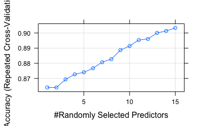

```r
plot(fit_rf_grid)
```

[output not shown]

[output cut: 24 more lines]

[output not shown]

```r
# Result from various methods are summarized below.
# We can see that C5.0 classifier method performs above other method both in term of accuracy and Kappa value
result1 = read.csv("/Volumes/USB128GB/2_DS_Project/Churn/result1.csv")
head(result1, n=7)
```

|  | Method | Accuracy | Kappa |
| --- | --- | --- | --- |
| 1 | GLM | 0.8758 | 0.3943 |
| 2 | RPART | 0.8872 | 0.3413 |
| 3 | C5.0 | 0.9598 | 0.8120 |
| 4 | BST | 0.9442 | 0.7182 |
| 5 | RF (search=random) | 0.9310 | 0.6576 |
| 6 | RF (search=grid) | 0.9166 | 0.5423 |
| 7 | GBM | 0.8998 | 0.4475 |

```r
# Most important variables in C5.0
varImp(fit_dtc50)
```

```
C5.0 variable importance

  only 20 most important variables shown (out of 69)

                              Overall
total_day_charge               100.00
total_night_minutes            100.00
total_eve_charge               100.00
number_customer_service_calls  100.00
international_planyes          100.00
total_day_minutes              100.00
stateNJ                        100.00
total_intl_minutes              99.58
voice_mail_planyes              99.01
account_length                  96.46
total_intl_calls                96.22
total_night_calls               89.71
stateMT                         78.31
stateUT                         70.60
stateOR                         66.67
stateNE                         65.83
stateOH                         61.84
stateWV                         53.62
total_eve_minutes               52.60
stateME                         51.61
```

```
[1] 18
```

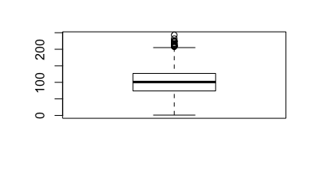

```r
# Remove outliers/impute the outliers
length(boxplot(train$account_length)$out)
```

```
[1] 208
```

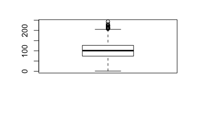

```r
min(boxplot(train$account_length)$out)
```

```r
quantile(train$account_length,prob=c(0.99))
```

```
99%
195
```

```r
# Convert outliers
train$account_length <- ifelse(train$account_length > quantile(train$account_length,prob=c(0.99)),
                        quantile(train$account_length,prob=c(0.99)),train$account_length)
```

```
[1] 0
```

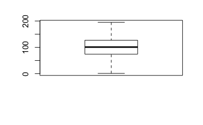

```r
# Verify the outliers
length(boxplot(train$account_length)$out)
```

```r
# Re-run the models on the transformed dataset
train_df = train[,-1]
traindf=train_df[,c(2,6:20)]
```

```r
# Use Decision tree based method
library(caret)
library(mlr)
library(rpart)
train_control <- trainControl(method = 'cv', number = 10)
metric <- 'Accuracy'
fit_dt <- caret::train(churn~.,data=train_df,
               trControl = train_control,
               method='rpart')
## for rpart, no dummy needs to be created
fit_dt
```

```
CART

3333 samples
  19 predictor
   2 classes: 'no', 'yes'

No pre-processing
Resampling: Cross-Validated (10 fold)
Summary of sample sizes: 2999, 2999, 3000, 3000, 3000, 2999, ...
Resampling results across tuning parameters:

  cp          Accuracy   Kappa
  0.07867495  0.8814992  0.3660398
  0.08488613  0.8559835  0.1367613
  0.08902692  0.8547823  0.1339259

Accuracy was used to select the optimal model using  the largest value.
The final value used for the model was cp = 0.07867495.
```

```r
predictions <- predict(fit_dt, test_df)
pred = cbind(test_df, predictions)
confusionMatrix(pred$churn,pred$predictions)
```

```
Confusion Matrix and Statistics

          Reference
Prediction   no  yes
       no  1419   24
       yes  164   60

               Accuracy : 0.8872
                 95% CI : (0.8711, 0.902)
    No Information Rate : 0.9496
    P-Value [Acc > NIR] : 1

                  Kappa : 0.3413
 Mcnemar's Test P-Value : <2e-16

            Sensitivity : 0.8964
            Specificity : 0.7143
         Pos Pred Value : 0.9834
         Neg Pred Value : 0.2679
             Prevalence : 0.9496
         Detection Rate : 0.8512
   Detection Prevalence : 0.8656
      Balanced Accuracy : 0.8053

       'Positive' Class : no
```

```r
varImp(fit_dt)
```

```
rpart variable importance

  only 20 most important variables shown (out of 69)

                              Overall
total_day_minutes             100.000
total_day_charge               93.072
number_customer_service_calls  79.443
international_planyes          55.175
number_vmail_messages          33.443
voice_mail_planyes             33.443
total_eve_minutes              14.576
total_eve_charge               14.576
total_intl_minutes              8.563
stateCT                         0.000
stateMS                         0.000
total_night_charge              0.000
stateTN                         0.000
stateDE                         0.000
stateID                         0.000
area_codearea_code_415          0.000
stateVA                         0.000
total_night_calls               0.000
stateWA                         0.000
stateAR                         0.000
```

```r
# Decision tree based method
# install.packages("C50")
library(C50)
fit_dtc50 <- caret::train(churn~., data = train_df, trControl = train_control, method='C5.0')
fit_dtc50
```

```
C5.0

3333 samples
  19 predictor
   2 classes: 'no', 'yes'

No pre-processing
Resampling: Cross-Validated (10 fold)
Summary of sample sizes: 3000, 3000, 2999, 2999, 3000, 3000, ...
Resampling results across tuning parameters:

  model  winnow  trials  Accuracy   Kappa
  rules  FALSE    1      0.9480957  0.7754282
  rules  FALSE   10      0.9528942  0.7967236
  rules  FALSE   20      0.9561984  0.8100411
  rules   TRUE    1      0.9501978  0.7851722
  rules   TRUE   10      0.9531981  0.7957722
  rules   TRUE   20      0.9565032  0.8098846
  tree   FALSE    1      0.9453948  0.7596107
  tree   FALSE   10      0.9537951  0.7978688
  tree   FALSE   20      0.9573960  0.8127101
  tree    TRUE    1      0.9477954  0.7709624
  tree    TRUE   10      0.9481047  0.7700600
  tree    TRUE   20      0.9553029  0.8037078

Accuracy was used to select the optimal model using  the largest value.
The final values used for the model were trials = 20, model = tree
 and winnow = FALSE.
```

```r
predictions <- predict(fit_dtc50, test_df)
pred = cbind(test_df, predictions)
confusionMatrix(pred$churn,pred$predictions)
```

```
Confusion Matrix and Statistics

          Reference
Prediction   no  yes
       no  1435    8
       yes   62  162

               Accuracy : 0.958
                 95% CI : (0.9472, 0.9671)
    No Information Rate : 0.898
    P-Value [Acc > NIR] : < 2.2e-16

                  Kappa : 0.799
 Mcnemar's Test P-Value : 2.378e-10

            Sensitivity : 0.9586
            Specificity : 0.9529
         Pos Pred Value : 0.9945
         Neg Pred Value : 0.7232
             Prevalence : 0.8980
         Detection Rate : 0.8608
   Detection Prevalence : 0.8656
      Balanced Accuracy : 0.9558

       'Positive' Class : no
```

```r
varImp(fit_dtc50)
```

```
C5.0 variable importance

  only 20 most important variables shown (out of 69)

                              Overall
stateDC                        100.00
stateHI                        100.00
total_eve_charge               100.00
total_day_minutes              100.00
international_planyes          100.00
number_customer_service_calls  100.00
total_intl_minutes              98.41
total_night_charge              97.54
stateAL                         97.48
stateIL                         96.16
stateMS                         94.72
total_day_calls                 93.52
number_vmail_messages           93.37
stateOR                         93.04
account_length                  92.89
total_eve_calls                 92.35
total_day_charge                91.81
total_intl_calls                91.33
stateMA                         91.00
stateIA                         90.79
```

```r
# Boosted Tree
#install.packages("bst")
library(bst)
fit_bstTree <- caret::train(churn~., data = train_df, trControl = train_control, method='bstTree')
fit_bstTree
```

```
Boosted Tree

3333 samples
  19 predictor
   2 classes: 'no', 'yes'

No pre-processing
Resampling: Cross-Validated (10 fold)
Summary of sample sizes: 3000, 3000, 3000, 2999, 2999, 3000, ...
Resampling results across tuning parameters:

  maxdepth  mstop  Accuracy   Kappa
  1          50    0.8667979  0.2986041
  1         100    0.8667979  0.2986041
  1         150    0.8667979  0.2986041
  2          50    0.8818076  0.4277264
  2         100    0.9103073  0.5846044
  2         150    0.9286050  0.6786118
  3          50    0.9333999  0.6862733
  3         100    0.9351981  0.6970871
  3         150    0.9390993  0.7203198

Tuning parameter 'nu' was held constant at a value of 0.1
Accuracy was used to select the optimal model using  the largest value.
The final values used for the model were mstop = 150, maxdepth = 3 and nu
 = 0.1.
```

```r
predictions <- predict(fit_bstTree, test_df)
pred = cbind(test_df, predictions)
confusionMatrix(pred$churn,pred$predictions)
```

```
Confusion Matrix and Statistics

          Reference
Prediction   no  yes
       no  1436    7
       yes   85  139

               Accuracy : 0.9448
                 95% CI : (0.9327, 0.9553)
    No Information Rate : 0.9124
    P-Value [Acc > NIR] : 4.126e-07

                  Kappa : 0.7219
 Mcnemar's Test P-Value : 9.923e-16

            Sensitivity : 0.9441
            Specificity : 0.9521
         Pos Pred Value : 0.9951
         Neg Pred Value : 0.6205
             Prevalence : 0.9124
         Detection Rate : 0.8614
   Detection Prevalence : 0.8656
      Balanced Accuracy : 0.9481

       'Positive' Class : no
```

```r
varImp(fit_bstTree)
```

```
ROC curve variable importance

                              Importance
total_day_charge                 100.000
total_day_minutes                100.000
international_plan                77.619
number_customer_service_calls     76.904
total_eve_minutes                 51.047
total_eve_charge                  51.040
voice_mail_plan                   45.413
number_vmail_messages             43.044
total_intl_calls                  42.305
total_intl_minutes                34.500
total_intl_charge                 34.500
total_night_charge                18.701
total_night_minutes               18.694
total_day_calls                   13.903
account_length                     7.498
total_eve_calls                    3.329
state                              2.001
total_night_calls                  1.013
area_code                          0.000
```

```r
# Random Forest, search=random
#install.packages("randomForest")
library(randomForest)
control <- caret::trainControl(method = 'repeatedcv',
                        number = 10,
                        repeats = 3,
                        search = 'random')
seed <- 1234
metric <- 'Accuracy'
set.seed(seed)
mtry <- sqrt(ncol(train_df))
fit_rf_random <- caret::train(churn~.,
                              data = train_df[1:500,],
                              method = 'rf',
                              metric=metric,
                              tuneLength=15,
                              trControl = control)
```

```r
# Random Forest, search = grid
library(randomForest)
control <- caret::trainControl(method = 'repeatedcv',
                        number = 10,
                        repeats = 3,
                        search = 'grid')
seed <- 1234
metric <- 'Accuracy'
set.seed(seed)
#mtry <- sqrt(ncol(train_df))
tunegrid <- expand.grid(.mtry = c(1:15))
fit_rf_grid <- caret::train(churn~.,
                              data = train_df[1:500,],
                              method = 'rf',
                              metric=metric,
                              tuneGrid = tunegrid,
                              trControl = control)
fit_rf_grid
```

```
Random Forest

500 samples
 19 predictor
  2 classes: 'no', 'yes'

No pre-processing
Resampling: Cross-Validated (10 fold, repeated 3 times)
Summary of sample sizes: 451, 450, 450, 450, 450, 449, ...
Resampling results across tuning parameters:

  mtry  Accuracy   Kappa
   1    0.8640395   0.00000000
   2    0.8626925  -0.00241744
   3    0.8693733   0.08127411
   4    0.8720536   0.11221452
   5    0.8733870   0.12229812
   6    0.8787339   0.17316695
   7    0.8780672   0.17269466
   8    0.8820536   0.21297667
   9    0.8880808   0.26113569
  10    0.8920547   0.30321980
  11    0.8960558   0.35101299
  12    0.8954288   0.34913747
  13    0.9000291   0.38686685
  14    0.9039904   0.42537127
  15    0.9060171   0.43662148

Accuracy was used to select the optimal model using  the largest value.
The final value used for the model was mtry = 15.
```

```r
predictions <- predict(fit_rf_grid , test_df)
pred = cbind(test_df, predictions)
confusionMatrix(pred$churn,pred$predictions)
```

```
Confusion Matrix and Statistics

          Reference
Prediction   no  yes
       no  1434    9
       yes  133   91

               Accuracy : 0.9148
                 95% CI : (0.9004, 0.9278)
    No Information Rate : 0.94
    P-Value [Acc > NIR] : 1

                  Kappa : 0.5221
 Mcnemar's Test P-Value : <2e-16

            Sensitivity : 0.9151
            Specificity : 0.9100
         Pos Pred Value : 0.9938
         Neg Pred Value : 0.4063
             Prevalence : 0.9400
         Detection Rate : 0.8602
   Detection Prevalence : 0.8656
      Balanced Accuracy : 0.9126

       'Positive' Class : no
```

```r
varImp(fit_rf_grid )
```

```
rf variable importance

  only 20 most important variables shown (out of 69)

                              Overall
total_day_charge              100.000
total_day_minutes              97.031
number_customer_service_calls  78.746
total_eve_charge               50.574
total_eve_minutes              48.700
total_day_calls                40.673
total_intl_minutes             38.905
international_planyes          36.273
total_intl_charge              35.991
total_intl_calls               32.450
total_night_minutes            29.522
total_night_charge             29.255
account_length                 28.928
total_eve_calls                27.837
total_night_calls              26.795
number_vmail_messages          13.960
stateMS                         7.881
stateME                         5.775
stateCO                         4.947
stateFL                         4.760
```

```r
# GBM
control <- caret::trainControl(method = 'repeatedcv',
                        number = 10,
                        repeats = 3,
                        search = 'grid')
seed <- 1234
metric <- 'Accuracy'
set.seed(seed)
fit_gbm <- caret::train(churn~.,
                              data = train_df[1:500,],
                              method = 'gbm',
                              metric=metric,
                              trControl = control)
fit_gbm
```

```
Stochastic Gradient Boosting

500 samples
 19 predictor
  2 classes: 'no', 'yes'

No pre-processing
Resampling: Cross-Validated (10 fold, repeated 3 times)
Summary of sample sizes: 451, 450, 450, 450, 450, 449, ...
Resampling results across tuning parameters:

  interaction.depth  n.trees  Accuracy   Kappa
  1                   50      0.8581038  0.08689997
  1                  100      0.8574763  0.13978647
  1                  150      0.8594104  0.17837177
  2                   50      0.8767982  0.25867370
  2                  100      0.8781059  0.33019401
  2                  150      0.8767862  0.34207388
  3                   50      0.8733864  0.25132124
  3                  100      0.8761048  0.33395323
  3                  150      0.8701571  0.31007093

Tuning parameter 'shrinkage' was held constant at a value of 0.1

Tuning parameter 'n.minobsinnode' was held constant at a value of 10
Accuracy was used to select the optimal model using  the largest value.
The final values used for the model were n.trees = 100, interaction.depth
 = 2, shrinkage = 0.1 and n.minobsinnode = 10.
```

```r
predictions <- predict(fit_gbm  , test_df)
pred = cbind(test_df, predictions)
confusionMatrix(pred$churn,pred$predictions)
```

```
Confusion Matrix and Statistics

          Reference
Prediction   no  yes
       no  1418   25
       yes  142   82

               Accuracy : 0.8998
                 95% CI : (0.8844, 0.9138)
    No Information Rate : 0.9358
    P-Value [Acc > NIR] : 1

                  Kappa : 0.4475
 Mcnemar's Test P-Value : <2e-16

            Sensitivity : 0.9090
            Specificity : 0.7664
         Pos Pred Value : 0.9827
         Neg Pred Value : 0.3661
             Prevalence : 0.9358
         Detection Rate : 0.8506
   Detection Prevalence : 0.8656
      Balanced Accuracy : 0.8377

       'Positive' Class : no
```

```r
varImp(fit_gbm)
```

```
gbm variable importance

  only 20 most important variables shown (out of 69)

                              Overall
total_day_minutes             100.000
number_customer_service_calls  43.387
total_intl_minutes             30.276
international_planyes          28.213
total_eve_minutes              25.102
total_day_calls                12.947
total_eve_calls                 9.899
total_intl_calls                9.767
account_length                  7.390
total_night_calls               5.445
total_night_minutes             5.390
number_vmail_messages           2.314
voice_mail_planyes              2.025
stateSC                         0.000
stateFL                         0.000
stateLA                         0.000
stateNH                         0.000
stateSD                         0.000
stateNJ                         0.000
stateNC                         0.000
```

```r
# Compare the accuracy before and after outlier removal
# Before Outlier removal
result1 = read.csv("/Volumes/USB128GB/2_DS_Project/Churn/result1.csv")
head(result1, n=7)
```

|  | Method | Accuracy | Kappa |
| --- | --- | --- | --- |
| 1 | GLM | 0.8758 | 0.3943 |
| 2 | RPART | 0.8872 | 0.3413 |
| 3 | C5.0 | 0.9598 | 0.8120 |
| 4 | BST | 0.9442 | 0.7182 |
| 5 | RF (search=random) | 0.9310 | 0.6576 |
| 6 | RF (search=grid) | 0.9166 | 0.5423 |
| 7 | GBM | 0.8998 | 0.4475 |

```r
# After Outlier removal
result1 = read.csv("/Volumes/USB128GB/2_DS_Project/Churn/result2.csv")
head(result1, n=7)
```

|  | Method | Accuracy | Kappa |
| --- | --- | --- | --- |
| 1 | RPART | 0.8872 | 0.3413 |
| 2 | C5.0 | 0.9580 | 0.7990 |
| 3 | BST | 0.9448 | 0.7219 |
| 4 | RF (search=random) | 0.9310 | 0.6576 |
| 5 | RF (search=grid) | 0.9148 | 0.5221 |
| 6 | GBM | 0.8998 | 0.4475 |

```r
# Validate if the outliers have any impact?
#We can see that removing outliers on variable account_length does not improve the accuracy and Kappa values, even for C5.0 where this variable is among ten most important variables.
```

## Answers

1. How to identify who is likely to churn? >We test different classifiers, including ensemble methods, to find the model that highest accuracy, as well as high Kappa value. The Kappa statistic (or value) is a metric that compares an Observed Accuracy with an Expected Accuracy (random chance). It is always less than or equal to 1. A value of 1 implies perfect agreement and values less than 1 imply less than perfect agreement.
2. What are the factors responsible for churn? >Using C5.0 classifiers, the 20 most important variables are: total_day_charge 100.00 total_night_minutes 100.00 total_eve_charge 100.00 number_customer_service_calls 100.00 international_planyes 100.00 total_day_minutes 100.00 stateNJ 100.00 total_intl_minutes 99.58 voice_mail_planyes 99.01 account_length 96.46 total_intl_calls 96.22 total_night_calls 89.71 stateMT 78.31 stateUT 70.60 stateOR 66.67 stateNE 65.83 stateOH 61.84 stateWV 53.62 total_eve_minutes 52.60 stateME 51.61
3. Who are most valuable customers >The most valuables customers are the ones who generate most revenues to the company in the form of charging (total of day, evening, night and international charges) and showing loyalty through high numbers of account length.
4. How valid is the churn prediction model? >The churn prediction model using Boosted C5.0 classifiers has accuracy of 0.9598 and Kappa value of 0.8120 (very good agreement).

## Resources:

http://www.pmean.com/definitions/kappa.htm http://www.euclidean.com/machine-learning-in-practice/2015/6/12/r-caret-and-parameter-tuning-c50 https://stats.stackexchange.com/questions/82162/cohens-kappa-in-plain-english